# Question 3: WebText API Proof of Concept

Scraping, cleaning and summarising a web article from a single link

Happy Mahlangu

12 November 2026

The whole pipeline is driven by one input, the web link in `params$url`. Everything below runs from that link, which is the core idea of the WebText API. The chosen page is the Wikipedia article **Climate change in Africa**, which fits the theme in the brief of treating language as environmental data.

# 3.1 Extracting clean web text into an R data structure

## Fair use of web scraping

Before any request is sent, the scraper checks the rules of the site. The design follows these fair use practices:

1. **robots.txt is checked** and the run stops if the path is disallowed.
2. **One page, one request.** The HTML is saved to disk and reused on later runs (`params$refresh = FALSE`), so the site is not hit again every time the notebook is knitted.
3. **A clear user agent** says what the client is and why it is visiting.
4. **Licensed content.** Wikipedia text is published under CC BY-SA 4.0, which allows reuse with attribution. The source link is stored with the data.
5. **No personal data** is collected and nothing is republished as is. The output is analysis and short extracts.

```r
check_scraping_allowed <- function(url) {
  allowed <- robotstxt::paths_allowed(url, warn = FALSE)
  if (!isTRUE(allowed)) stop("robots.txt does not allow scraping: ", url)
  allowed
}

check_scraping_allowed(params$url)
```

```
## [1] TRUE
```

## Fetching the page

```r
fetch_page <- function(url, cache_dir = "../data/raw", refresh = FALSE) {
  cache_file <- file.path(cache_dir, paste0("q3_", str_replace_all(basename(url), "[^A-Za-z0-9]", "_"), ".html"))
  if (file.exists(cache_file) && !refresh) {
    return(list(html = read_html(cache_file, encoding = "UTF-8"), cache_file = cache_file, from_cache = TRUE))
  }
  Sys.sleep(1)  # be polite even for a single request
  resp <- GET(url, user_agent("itbda-student-webtext-poc/1.0 (educational text mining project)"))
  stop_for_status(resp)
  html_text <- content(resp, as = "text", encoding = "UTF-8")
  dir.create(cache_dir, showWarnings = FALSE, recursive = TRUE)
  writeLines(html_text, cache_file, useBytes = TRUE)
  list(html = read_html(html_text), cache_file = cache_file, from_cache = FALSE)
}

page <- fetch_page(params$url, refresh = params$refresh)
page[c("cache_file", "from_cache")]
```

```
## $cache_file
## [1] "../data/raw/q3_Climate_change_in_Africa.html"
##
## $from_cache
## [1] TRUE
```

## Extracting the article into a data frame

The article body lives inside `.mw-parser-output`. Headings and paragraphs are read in page order so that every paragraph keeps the section and subsection it belongs to. Infoboxes, tables, image captions and navigation boxes are left out by only keeping `h2`, `h3` and `p` nodes.

```r
extract_article <- function(html) {
  body  <- html_element(html, "#mw-content-text .mw-parser-output")
  nodes <- html_elements(body, xpath = ".//h2 | .//h3 | .//p")

  section <- "Introduction"; subsection <- NA_character_
  rows <- vector("list", length(nodes))
  for (i in seq_along(nodes)) {
    tag  <- html_name(nodes[[i]])
    text <- html_text2(nodes[[i]])
    if (tag == "h2") { section <- text; subsection <- NA_character_; next }
    if (tag == "h3") { subsection <- text; next }
    rows[[i]] <- tibble(section = section, subsection = subsection, raw_text = text)
  }
  bind_rows(rows) %>% mutate(para_id = row_number(), .before = 1)
}

webtext <- list(
  meta = list(
    url           = params$url,
    title         = html_text2(html_element(page$html, "#firstHeading")),
    last_modified = html_text2(html_element(page$html, "#footer-info-lastmod")),
    retrieved     = format(file.info(page$cache_file)$mtime, "%Y-%m-%d %H:%M"),
    licence       = "CC BY-SA 4.0, Wikipedia contributors"
  ),
  paragraphs = extract_article(page$html)
)

str(webtext, max.level = 2)
```

```
## List of 2
##  $ meta      :List of 5
##   ..$ url          : chr "https://en.wikipedia.org/wiki/Climate_change_in_Africa"
##   ..$ title        : chr "Climate change in Africa"
##   ..$ last_modified: chr "This page was last edited on 16 October 2026, at 22:35 (UTC)."
##   ..$ retrieved    : chr "2026-11-12 19:15"
##   ..$ licence      : chr "CC BY-SA 4.0, Wikipedia contributors"
##  $ paragraphs: tibble [101 × 4] (S3: tbl_df/tbl/data.frame)
```

```r
webtext$paragraphs %>% count(section, name = "paragraphs")
```

| section | paragraphs |
| --- | --- |
| Adaptation | 39 |
| Greenhouse gas emissions | 1 |
| Impacts | 6 |
| Impacts by region | 17 |
| Introduction | 6 |
| Society and culture | 3 |
| Socioeconomic impacts | 17 |
| Water scarcity | 12 |

```r
webtext$paragraphs %>% slice(1:4) %>% mutate(raw_text = str_trunc(raw_text, 160))
```

| para_id | section | subsection | raw_text |
| --- | --- | --- | --- |
| 1 | Introduction | NA |  |
| 2 | Introduction | NA | Climate change in Africa is a serious threat because the continent is one of the most vulnerable regions to the effects of climate change, despite being resp… |
| 3 | Introduction | NA | Climate change intensifies existing socioeconomic vulnerabilities. Large segments of the African population depend on climate-sensitive livelihoods such as a… |
| 4 | Introduction | NA | Agriculture is one of the most vulnerable sectors, as most African farmers rely on rainfed crops. Reduced and unpredictable rainfall, combined with higher te… |

The result is a named list, a small R object that an API can return as JSON. `meta` holds the provenance and `paragraphs` is a tidy data frame with one row per paragraph.

# 3.2 Preprocessing the text

The raw paragraphs still carry noise that is not part of the content. A quick profile shows how much:

```r
webtext$paragraphs %>%
  summarise(
    paragraphs          = n(),
    empty_or_short      = sum(str_count(raw_text, "\\S+") < 12),
    citation_markers    = sum(str_count(raw_text, "\\[[^\\]]{1,30}\\]")),
    non_content_section = sum(section %in% c("See also", "References", "External links", "Further reading", "Notes")),
    non_ascii_chars     = sum(str_count(raw_text, "[^\\x01-\\x7F]"))
  )
```

| paragraphs | empty_or_short | citation_markers | non_content_section | non_ascii_chars |
| --- | --- | --- | --- | --- |
| 101 | 1 | 266 | 0 | 53 |

The cleaning is done in two layers. Sentence level text stays readable because summaries are made from real sentences. Word level text is reduced to meaningful lemmas for counting.

| Step | Technique | Purpose |
| --- | --- | --- |
| 1 | Drop non content sections (See also, References, External links) | Removes link lists and bibliography |
| 2 | Strip citation markers such as [12], [a] and [citation needed] | Wikipedia footnotes are not part of the prose |
| 3 | Normalise unicode quotes, dashes and non breaking spaces, collapse whitespace | One consistent character set |
| 4 | Remove very short paragraphs and duplicates | Captions and stubs carry little information |
| 5 | Split into sentences and drop fragments under 6 words | Units for extractive summarisation |
| 6 | Lower case, remove numbers, punctuation and stop words (plus page boilerplate words) | Keeps content words only |
| 7 | Lemmatise | “droughts” and “drought” count as one term |

```r
drop_sections <- c("See also", "References", "External links", "Further reading", "Notes")

clean_sentence_text <- function(x) {
  x %>%
    str_remove_all("\\[[^\\]]{1,30}\\]") %>%                        # 2
    str_replace_all("[\\u2018\\u2019]", "'") %>%                      # 3
    str_replace_all("[\\u201C\\u201D]", "\"") %>%
    str_replace_all("[\\u2013\\u2014]", " to ") %>%
    str_replace_all("[\\u00A0\\u2009\\u202F]", " ") %>%
    str_replace_all("\\s+([,.;:])", "\\1") %>%
    str_squish()
}

paras <- webtext$paragraphs %>%
  filter(!section %in% drop_sections) %>%                           # 1
  mutate(text = clean_sentence_text(raw_text)) %>%
  filter(str_count(text, "\\S+") >= 12) %>%                        # 4
  distinct(text, .keep_all = TRUE)

sentences <- paras %>%
  select(para_id, section, text) %>%
  unnest_tokens(sentence, text, token = "sentences", to_lower = FALSE) %>%   # 5
  filter(str_count(sentence, "\\S+") >= 6) %>%
  mutate(sentence_id = row_number(), .before = 1)

boilerplate <- c("climate", "change", "africa", "african", "wikipedia", "also", "can", "may",
                 "will", "however", "including", "et", "al")

words <- sentences %>%
  select(sentence_id, section, sentence) %>%
  unnest_tokens(word, sentence) %>%                                  # 6
  filter(!str_detect(word, "\\d"), !word %in% stop_words$word) %>%
  mutate(lemma = lemmatize_words(word)) %>%                          # 7
  filter(!lemma %in% c(stop_words$word, boilerplate), nchar(lemma) > 2)

tibble(
  stage = c("Raw paragraphs", "Clean paragraphs", "Sentences", "Content words (lemmas)", "Unique lemmas"),
  count = c(nrow(webtext$paragraphs), nrow(paras), nrow(sentences), nrow(words), n_distinct(words$lemma))
)
```

| stage | count |
| --- | --- |
| Raw paragraphs | 101 |
| Clean paragraphs | 100 |
| Sentences | 322 |
| Content words (lemmas) | 3843 |
| Unique lemmas | 1231 |

```r
paras %>% slice_max(str_count(raw_text, "\\["), n = 1, with_ties = FALSE) %>% select(raw_text, text) %>% t() %>% as.data.frame() %>%
  setNames("Before and after cleaning") %>% mutate(across(everything(), ~ str_trunc(.x, 400)))
```

|  | Before and after cleaning |
| --- | --- |
| raw_text | Eastern Africa has witnessed frequent and severe droughts in recent decades, as well as devastating floods. Trends in rainfall since the 1980s show a general decrease in March – May (MAM) seasonal rai… |
| text | Eastern Africa has witnessed frequent and severe droughts in recent decades, as well as devastating floods. Trends in rainfall since the 1980s show a general decrease in March to May (MAM) seasonal ra… |

```r
dir.create("../data/processed", showWarnings = FALSE)
write_csv(paras %>% select(para_id, section, subsection, text), "../data/processed/q3_paragraphs_clean.csv")
```

“climate”, “change” and “africa” are removed at word level because they are in the page title and appear in nearly every sentence. Keeping them would push them to the top of every chart without telling us anything new.

# 3.3 Text summarisation

## Technique 1: Word frequency sentence scoring (Luhn method)

```r
word_freq <- words %>% count(lemma, sort = TRUE) %>% mutate(weight = n / max(n))

freq_scores <- words %>%
  left_join(word_freq, by = "lemma") %>%
  group_by(sentence_id) %>%
  summarise(freq_score = sum(weight) / sqrt(n()), .groups = "drop")   # sqrt damps the bias to long sentences

freq_summary <- sentences %>%
  inner_join(freq_scores, by = "sentence_id") %>%
  slice_max(freq_score, n = params$n_sentences) %>%
  arrange(sentence_id)

freq_summary %>% select(sentence_id, section, sentence)
```

| sentence_id | section | sentence |
| --- | --- | --- |
| 65 | Socioeconomic impacts | The impacts include higher temperatures, droughts, changing rainfall patterns, and increased climate variability. |
| 221 | Impacts by region | Others refer to this as a period of “hydrological intensification” with much of the annual rainfall increase coming from more severe rain events and sometimes flooding rather than more frequent rainfa… |
| 250 | Adaptation | The World Health Organization’s report “Adaptation to Climate Change in Africa Plan of Action for the Health Sector 2012 to 2016” is intended to “provide a comprehensive and evidence-based coordinated… |
| 263 | Adaptation | Key adaptations in northern Africa relate to increased risk of water scarcity (resulting from a combination of climate change affecting water availability and increasing demand). |
| 274 | Adaptation | In Eastern Africa adaptation options are varied, including improving use of climate information, actions in the agriculture and livestock sector, and in the water sector. |
| 315 | Adaptation | South Africa has adopted in August 2020 its National Climate Change Adaptation Strategy, which “acts as a common reference point for climate change adaptation efforts in South Africa, and it provides … |

## Technique 2: TextRank (graph based)

TextRank builds a graph where each sentence is a node and edges are weighted by how many lemmas two sentences share. PageRank then finds the sentences that are most connected to the rest of the article, which are the ones that best represent it.

```r
tr <- textrank_sentences(
  data        = sentences %>% transmute(textrank_id = sentence_id, sentence),
  terminology = words %>% transmute(textrank_id = sentence_id, lemma)
)

textrank_summary <- tr$sentences %>%
  rename(sentence_id = textrank_id, textrank = textrank) %>%
  slice_max(textrank, n = params$n_sentences) %>%
  arrange(sentence_id) %>%
  left_join(sentences %>% select(sentence_id, section), by = "sentence_id")

textrank_summary %>% select(sentence_id, section, sentence)
```

| sentence_id | section | sentence |
| --- | --- | --- |
| 26 | Impacts | It is estimated that by 2030, the people of Africa will be exposed to a rise in sea level due to an increase in temperature. |
| 65 | Socioeconomic impacts | The impacts include higher temperatures, droughts, changing rainfall patterns, and increased climate variability. |
| 101 | Socioeconomic impacts | The agriculture sector is sensitive to climate variability, especially the inter-annual variability of precipitation, temperature patterns, and extreme weather events (droughts and floods). |
| 114 | Socioeconomic impacts | Climate change in Kenya is expected to have large impacts on the agricultural sector, which is predominantly rain-fed and thus highly vulnerable to changes in temperature and rainfall patterns, and ex… |
| 264 | Adaptation | Reduced water availability, in turn, interacts with increasing temperatures to create need for adaptation among rainfed wheat production and changing disease risk (for example from leishmaniasis). |
| 274 | Adaptation | In Eastern Africa adaptation options are varied, including improving use of climate information, actions in the agriculture and livestock sector, and in the water sector. |

## Technique 3: LexRank (TF-IDF cosine similarity)

LexRank is also graph based but compares sentences with TF-IDF weighted cosine similarity, so rare shared words count for more than common ones.

```r
lex <- lexRank(sentences$sentence, docId = sentences$sentence_id,
               n = params$n_sentences, continuous = TRUE, returnTies = FALSE,
               usePageRank = TRUE, removePunc = TRUE, removeNum = TRUE, toLower = TRUE,
               stemWords = TRUE, rmStopWords = TRUE, Verbose = FALSE)

lexrank_summary <- lex %>%
  mutate(sentence_id = as.integer(docId)) %>%
  arrange(sentence_id) %>%
  left_join(sentences %>% select(sentence_id, section), by = "sentence_id")

lexrank_summary %>% select(sentence_id, section, sentence)
```

| sentence_id | section | sentence |
| --- | --- | --- |
| 1 | Introduction | Climate change in Africa is a serious threat because the continent is one of the most vulnerable regions to the effects of climate change, despite being responsible for less than 4% of global greenhou… |
| 65 | Socioeconomic impacts | The impacts include higher temperatures, droughts, changing rainfall patterns, and increased climate variability. |
| 68 | Socioeconomic impacts | Africa will be one of the regions most impacted by the adverse effects of climate change. |
| 91 | Socioeconomic impacts | The impacts of climate change on agricultural production in Africa will have serious implications for food security and livelihoods. |
| 121 | Socioeconomic impacts | Climate change will significantly affect agriculture in West Africa by increasing the variability in food production, access and availability. |
| 185 | Impacts by region | In the future, both rainfall and temperature are projected to change over Eastern Africa. |

## Comparing the summaries

```r
picked <- list(Frequency = freq_summary$sentence_id,
               TextRank  = textrank_summary$sentence_id,
               LexRank   = lexrank_summary$sentence_id)

jaccard <- function(a, b) length(intersect(a, b)) / length(union(a, b))

summary_stats <- tibble(
  method = names(picked),
  sentences_kept = lengths(picked),
  words_kept = sapply(picked, function(ids) sum(str_count(sentences$sentence[ids], "\\S+"))),
  compression_pct = round(100 * words_kept / sum(str_count(sentences$sentence, "\\S+")), 1),
  sections_covered = sapply(picked, function(ids) n_distinct(sentences$section[ids]))
)
summary_stats
```

| method | sentences_kept | words_kept | compression_pct | sections_covered |
| --- | --- | --- | --- | --- |
| Frequency | 6 | 222 | 2.8 | 3 |
| TextRank | 6 | 145 | 1.8 | 3 |
| LexRank | 6 | 117 | 1.5 | 3 |

```r
outer(names(picked), names(picked), Vectorize(function(a, b) round(jaccard(picked[[a]], picked[[b]]), 2))) %>%
  `dimnames<-`(list(names(picked), names(picked)))
```

```
##           Frequency TextRank LexRank
## Frequency      1.00     0.20    0.09
## TextRank       0.20     1.00    0.09
## LexRank        0.09     0.09    1.00
```

## Section by section summary

A single short summary can miss whole parts of a long article. A structured summary picks the highest TextRank sentence inside each section, giving a one line digest per section.

```r
tr$sentences %>%
  rename(sentence_id = textrank_id) %>%
  left_join(sentences %>% select(sentence_id, section), by = "sentence_id") %>%
  group_by(section) %>%
  slice_max(textrank, n = 1, with_ties = FALSE) %>%
  ungroup() %>%
  arrange(sentence_id) %>%
  transmute(section, key_sentence = sentence)
```

| section | key_sentence |
| --- | --- |
| Introduction | Climate change is causing increasingly erratic rainfall patterns, more frequent extreme weather events such as droughts and floods, and rising sea-surface temperatures across the continent. |
| Greenhouse gas emissions | Africa’s per person greenhouse gas emissions are low compared to other continents. |
| Impacts | It is estimated that by 2030, the people of Africa will be exposed to a rise in sea level due to an increase in temperature. |
| Socioeconomic impacts | The impacts include higher temperatures, droughts, changing rainfall patterns, and increased climate variability. |
| Water scarcity | Climate change, and resulting in increased temperatures, storms, droughts, and rising sea levels, will affect the incidence and distribution of infectious disease across the globe. |
| Impacts by region | The global mean temperature in this region is to increase by 1.5 °C to 2 °C. |
| Adaptation | In Eastern Africa adaptation options are varied, including improving use of climate information, actions in the agriculture and livestock sector, and in the water sector. |
| Society and culture | This pattern of parachute science, in turn both prevents local researchers from doing groundbreaking work, because they do not have the funding for experimental activities and reduces investment in lo… |

## Visualisation 1: Most frequent terms

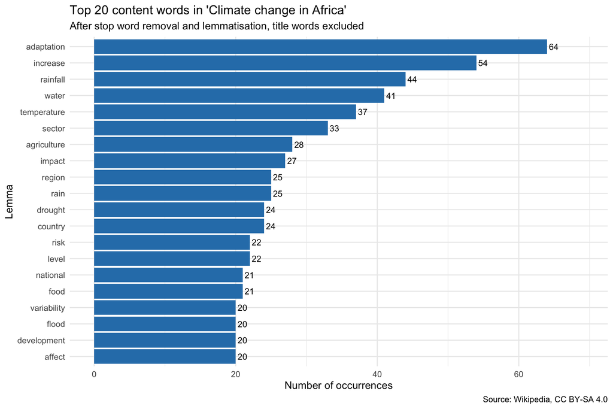

```r
word_freq %>%
  slice_max(n, n = 20) %>%
  ggplot(aes(n, reorder(lemma, n))) +
  geom_col(fill = "#2C7FB8") +
  geom_text(aes(label = n), hjust = -0.2, size = 3.2) +
  labs(title = "Top 20 content words in 'Climate change in Africa'",
       subtitle = "After stop word removal and lemmatisation, title words excluded",
       x = "Number of occurrences", y = "Lemma",
       caption = "Source: Wikipedia, CC BY-SA 4.0") +
  expand_limits(x = max(word_freq$n) * 1.08) +
  theme_minimal()
```

## Visualisation 2: Bigram network

Pairs of words that appear next to each other at least three times are drawn as a network. Clusters in the network show the main ideas in the article. The pair “climate change” is left out because it is the page title and occurs 101 times.

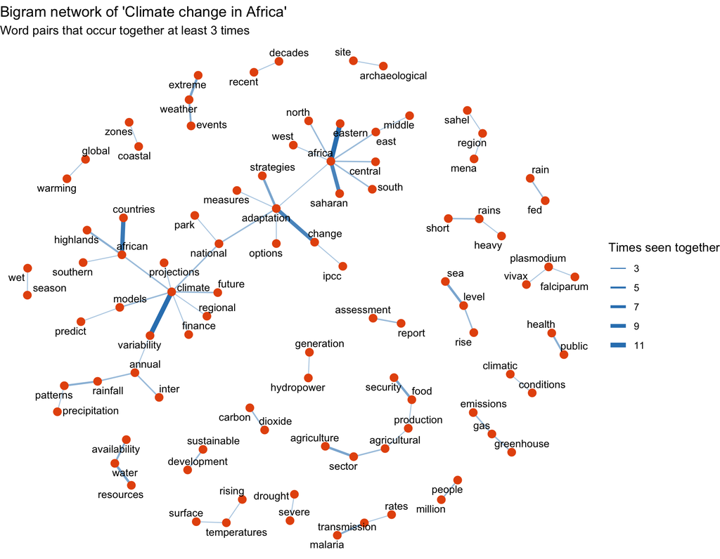

```r
bigrams <- sentences %>%
  unnest_tokens(bigram, sentence, token = "ngrams", n = 2) %>%
  separate(bigram, c("w1", "w2"), sep = " ") %>%
  filter(!w1 %in% stop_words$word, !w2 %in% stop_words$word,
         !str_detect(w1, "\\d"), !str_detect(w2, "\\d")) %>%
  count(w1, w2, sort = TRUE) %>%
  filter(!(w1 == "climate" & w2 == "change"))   # the page title, 101 times, would swamp the graph

bigrams %>%
  filter(n >= 3) %>%
  graph_from_data_frame() %>%
  ggraph(layout = "fr") +
  geom_edge_link(aes(edge_alpha = n, edge_width = n), colour = "#3182BD", show.legend = TRUE) +
  geom_node_point(colour = "#E6550D", size = 3) +
  geom_node_text(aes(label = name), repel = TRUE, size = 3.3) +
  scale_edge_width(range = c(0.4, 2), name = "Times seen together") +
  scale_edge_alpha(range = c(0.4, 1), guide = "none") +
  labs(title = "Bigram network of 'Climate change in Africa'",
       subtitle = "Word pairs that occur together at least 3 times") +
  theme_void()
```

## Visualisation 3: Distinctive terms per section (TF-IDF)

Treating each section as its own document, TF-IDF picks the words that are common in a section but rare in the rest of the article. This works as a keyword summary of every section.

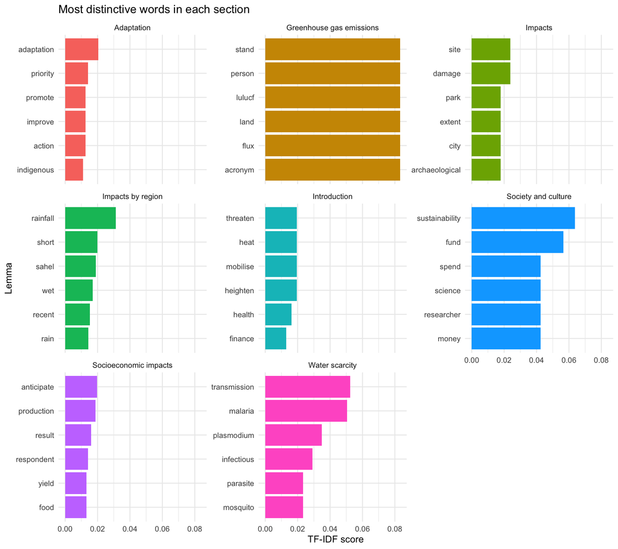

```r
words %>%
  count(section, lemma) %>%
  bind_tf_idf(lemma, section, n) %>%
  group_by(section) %>%
  slice_max(tf_idf, n = 6, with_ties = FALSE) %>%
  ungroup() %>%
  mutate(lemma = reorder_within(lemma, tf_idf, section)) %>%
  ggplot(aes(tf_idf, lemma, fill = section)) +
  geom_col(show.legend = FALSE) +
  facet_wrap(~ section, scales = "free_y", ncol = 3) +
  scale_y_reordered() +
  labs(title = "Most distinctive words in each section",
       x = "TF-IDF score", y = "Lemma") +
  theme_minimal(base_size = 10)
```

## Visualisation 4: Where the summary sentences come from

Each point is a sentence plotted by its position in the article and its TextRank score. Sentences picked by any of the three methods are coloured.

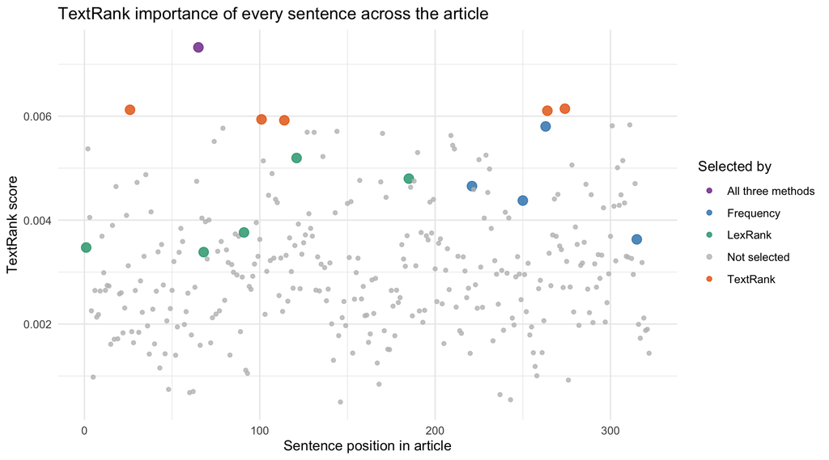

```r
tr$sentences %>%
  rename(sentence_id = textrank_id) %>%
  left_join(sentences %>% select(sentence_id, section), by = "sentence_id") %>%
  mutate(picked_by = case_when(
    sentence_id %in% Reduce(intersect, picked) ~ "All three methods",
    sentence_id %in% textrank_summary$sentence_id ~ "TextRank",
    sentence_id %in% lexrank_summary$sentence_id ~ "LexRank",
    sentence_id %in% freq_summary$sentence_id ~ "Frequency",
    TRUE ~ "Not selected")) %>%
  ggplot(aes(sentence_id, textrank, colour = picked_by, size = picked_by != "Not selected")) +
  geom_point(alpha = 0.8) +
  scale_size_manual(values = c(1.2, 3.2), guide = "none") +
  scale_colour_manual(values = c("All three methods" = "#7B3294", "TextRank" = "#E66101",
                                 "LexRank" = "#1B9E77", "Frequency" = "#2C7FB8",
                                 "Not selected" = "grey75"), name = "Selected by") +
  labs(title = "TextRank importance of every sentence across the article",
       x = "Sentence position in article", y = "TextRank score") +
  theme_minimal()
```

## Visualisation 5: Tone of each section

The Bing lexicon labels words as positive or negative. Net sentiment per 100 words summarises the tone of each section.

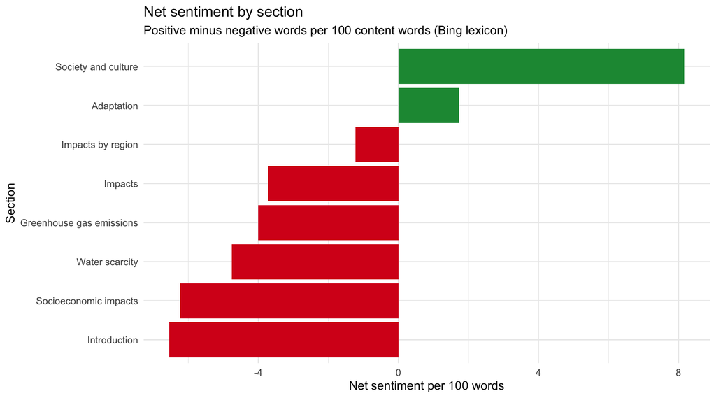

```r
sentences %>%
  unnest_tokens(word, sentence) %>%
  inner_join(get_sentiments("bing"), by = "word", relationship = "many-to-many") %>%
  count(section, sentiment) %>%
  pivot_wider(names_from = sentiment, values_from = n, values_fill = 0) %>%
  left_join(words %>% count(section, name = "content_words"), by = "section") %>%
  mutate(net_per_100 = 100 * (positive - negative) / content_words) %>%
  ggplot(aes(net_per_100, reorder(section, net_per_100), fill = net_per_100 > 0)) +
  geom_col(show.legend = FALSE) +
  scale_fill_manual(values = c("TRUE" = "#1A9641", "FALSE" = "#D7191C")) +
  labs(title = "Net sentiment by section",
       subtitle = "Positive minus negative words per 100 content words (Bing lexicon)",
       x = "Net sentiment per 100 words", y = "Section") +
  theme_minimal()
```

## Findings

**What the article is about.** After removing the title words, the most frequent lemmas are *adaptation* (64), *increase* (54), *rainfall* (44), *water* (41) and *temperature* (37). Together they show that the article is less about the science of global warming and more about how a hotter, less predictable climate plays out through water and rain, and how Africa responds. *Agriculture*, *drought*, *food* and *flood* in the top 20 point to farming and food supply as the main channel of harm.

**Main idea clusters.** The bigram network splits into a few clear groups: a weather cluster (*extreme weather events*, *rainfall patterns*, *sea level rise*, *heavy rains*), a food and farming cluster (*agriculture sector*, *food security*, *rain fed*, *agricultural production*), a health cluster (*malaria transmission*, *plasmodium falciparum*, *public health*), a policy cluster (*national adaptation*, *adaptation strategies*, *climate finance*, *sustainable development*) and a regional cluster (*eastern africa*, *saharan africa*, *north africa*, *central africa*). These five clusters are effectively a table of contents built from the language alone.

**What each section adds.** The TF-IDF chart shows that sections are well separated. *Water scarcity* is really about disease (*malaria*, *plasmodium*, *mosquito*, *parasite*), which a reader would not guess from the heading. *Impacts by region* focuses on rainfall seasons in the *Sahel*. *Society and culture* is about who funds and does the research (*researcher*, *fund*, *money*, *science*).

**Summaries.** All three methods compress the 322 cleaned sentences to six, which is under 3% of the words. They agree on only one sentence (sentence 65, “The impacts include higher temperatures, droughts, changing rainfall patterns, and increased climate variability”), which makes it the single best one line summary of the page. Beyond that they behave differently, as the Jaccard overlap of 0.09 to 0.20 shows:

- The **frequency method** prefers long sentences full of common terms. It picked policy heavy sentences from the Adaptation section, so its summary reads like a list of programmes.
- **TextRank** prefers short, general sentences that share words with many others. Its picks centre on agriculture and rainfall, the core thread of the article.
- **LexRank** chose the opening sentence of the article, which says Africa is among the most vulnerable regions while producing less than 4% of global emissions. TF-IDF weighting rewards that sentence for combining rare and central ideas.

The position chart shows that high scoring sentences are spread across the whole article rather than bunched at the start, so simply taking the first few sentences would miss a lot. Sentence 65 stands well above the rest, which agrees with all three methods choosing it. LexRank leans towards the first 190 sentences, while the frequency method leans towards the end of the article where the Adaptation section sits. Because one six sentence summary covers only three of the eight sections, the section by section TextRank digest is the most complete summary for a reader.

**Tone.** Sentiment is negative in the sections that describe the problem (Introduction at -6.5 and Socioeconomic impacts at -6.2 net words per 100) and turns positive in Adaptation (+1.7) and Society and culture (+8.2), driven by words such as *sustainable*, *improving* and *support*. The article therefore follows a problem then response structure. The most common negative words are *risk*, *drought* and *vulnerable*.

**Limitations.** Wikipedia is written by many editors, so some sections read like lists of projects, which inflates the frequency score of long sentences. The Bing lexicon is general purpose and reads words such as *well* and *like* as positive even when they are not used that way. The summaries are extractive, so they can only reuse sentences already on the page.

## Packaging it as an API call

All the steps above are wrapped in one function, so a new link is the only input needed. This is the shape the WebText API would expose, for example behind a `plumber` endpoint.

```r
webtext_api <- function(url, n_sentences = 5) {
  check_scraping_allowed(url)
  pg <- fetch_page(url)
  article <- extract_article(pg$html) %>%
    filter(!section %in% drop_sections) %>%
    mutate(text = clean_sentence_text(raw_text)) %>%
    filter(str_count(text, "\\S+") >= 12)
  sents <- article %>%
    unnest_tokens(sentence, text, token = "sentences", to_lower = FALSE) %>%
    filter(str_count(sentence, "\\S+") >= 6) %>%
    mutate(id = row_number())
  title <- html_text2(html_element(pg$html, "#firstHeading"))
  title_words <- unlist(str_split(str_to_lower(title), "\\W+"))
  terms <- sents %>%
    unnest_tokens(word, sentence) %>%
    filter(!word %in% c(stop_words$word, title_words), !str_detect(word, "\\d")) %>%
    mutate(lemma = lemmatize_words(word))
  ranked <- textrank_sentences(sents %>% transmute(textrank_id = id, sentence),
                               terms %>% transmute(textrank_id = id, lemma))
  list(
    url = url,
    title = title,
    sentences = nrow(sents),
    keywords = terms %>% count(lemma, sort = TRUE) %>% head(10) %>% pull(lemma),
    summary = summary(ranked, n = n_sentences, keep.sentence.order = TRUE)
  )
}

result <- webtext_api(params$url, n_sentences = 4)
str(result[c("title", "sentences", "keywords")])
```

```
## List of 3
##  $ title    : chr "Climate change in Africa"
##  $ sentences: int 322
##  $ keywords : chr [1:10] "adaptation" "increase" "african" "rainfall" ...
```

```r
cat(paste("-", result$summary), sep = "\n")
```

```
## - It is estimated that by 2030, the people of Africa will be exposed to a rise in sea level due to an increase in temperature.
## - The impacts include higher temperatures, droughts, changing rainfall patterns, and increased climate variability.
## - The agriculture sector is sensitive to climate variability, especially the inter-annual variability of precipitation, temperature patterns, and extreme weather events (droughts and floods).
## - In Eastern Africa adaptation options are varied, including improving use of climate information, actions in the agriculture and livestock sector, and in the water sector.
```